# Final Project for Econometrics Course: Simulations inspired by paper from Ito (AER, 2005)

Author

Manon Vallat, Youenn Mandon

```r
library(tidyverse)
library(ggplot2)
library(knitr)
library(fixest)
library(tibble)
library(MASS)
library(tidyr)
library(dplyr)
library(purrr)
library(broom)
library(fixest)
library(stargazer)
library(modelsummary)

set.seed(666)
```

# This document

In this document, we show our code and explain our calibration choices and generating processes. We also give some interpretations to our results. The document is structured in three parts, for our three different DGP from the simpliest to the most complex. In the first part, we were able to run only a part of our code containing more than 8 millions observations. Some code are thus presented but only runned for smaller samples. Our second DGP was about generating the treatment in a random way, potentially using categorical variables. Unfortunately, we did not had time to generate this dataset. The third DGP is a more complex one which aims at retrieving the heterogeneous effects of the Ito’s article. The beginning of our code and generating data function are presented but we were not able to generate this more complex dataset.

# Simple simulation

We start this project by simulating a very simple situation with a simple DGP. It will help implement more complicated models later. As we would like to simulate a RDD approach, our first goal is to generate an underlying variable–the income–which influences both consumption and the treatment take up. In this first model, we try to generate an income variable, a treatment variable and an electricity consumption variable. As the treatment is still randomly allocated among the richest incomes, the RDD is not relevant in this first version of the model. It will be the case in the second simulation. We still try different bandwdith’s sizes but it should not change our estimates.

## Data set structure

### Elements

#### Number of observations

We construct a panel data for 3,680,000 households in California during 24 months from January 2004 to December 2005. 3,680,000 is the estimated number of households with an SCE account–the company providing electricity–in December 2004. This is inspired from the data available in the paper, where SCE is estimated to have 3,500,000 households clients that kept their accounts between June 2004 and June 2005, and where there are around 1,000 account opened every day. To make the model simpler, we assume clients are not allowed to close their account. This way, with a frequency of 30,000 (= 30 * 1,000) accounts opened per month, there should be 3,680,000 (3,500,000 + 6*30,000) accounts in December 2004.

$N_c$ = 3,680,000

We then create a panel of 24 periods corresponding to the 24 months of 2004 and 2005.

$N_t$ = 24

#### Income

Income is drawn from a log-normal distribution for every household. We then add a noise for every observation of the time period to obtain the `monthly_income` variable.

$baseline\_income + noise\_income = monthly\_income$

#### Modeling treatment

##### Opening date of the electricity account

We want to generate the dates when households opened their account during 2004–the max bandwidth being 6 months. As the opening date is the variable behind the treatment take up, and we want the treatment not to be random in the more complicated model (in this case we could use a simple DiD framework rather than a RDD), we correlate the opening date of electricity account with the income variable. One might imagine a situation with different economical cycles: the richest households would be over represented in the population of households opening accounts during tough times, while the poorest households would be under represented.

In this first simulation, only the top 10% richest households (`q = 0.9`) are selected to open an account in 2004. This pre-treatment population is tantamount to 368,000 households, which is relevant with the hypothesis that there are 30,000 accounts opened every month (12*30,000 = 360,000). This selection bias into pre-treatment is the main flaw of this first simulation. The value 0 are attributed to “poorer” households that are assumed to have opened their account before 2004 or after December 2004.

##### Treatment dummy

The treatment depends on the cutoff date and the opening date of the account. Our cutoff date is the same as the one in the article which is June, 6th 2004, or month number 6 as we use months to make things easier ($cutoff$ = 6)

As the rebate program is targeting the electricity consumption of summer 2005 (and hopefully beyond this date) we can write the treatment dummy $D_{it}$ the following way:

$$D_{it} = D_i \times D_t$$

$$D_i = \begin{cases}
1 & \text{if } date\_account < cutoff, \\
0 & \text{else}
\end{cases}$$

##### Electricity consumption

The electricity consumption $kWh$ is a function of the treatment dummy and of income, such that :

$kWh = \beta_1 \times D_{it} + \beta_2 \times monthly\_income + model\_noise$

##### Causal diagram

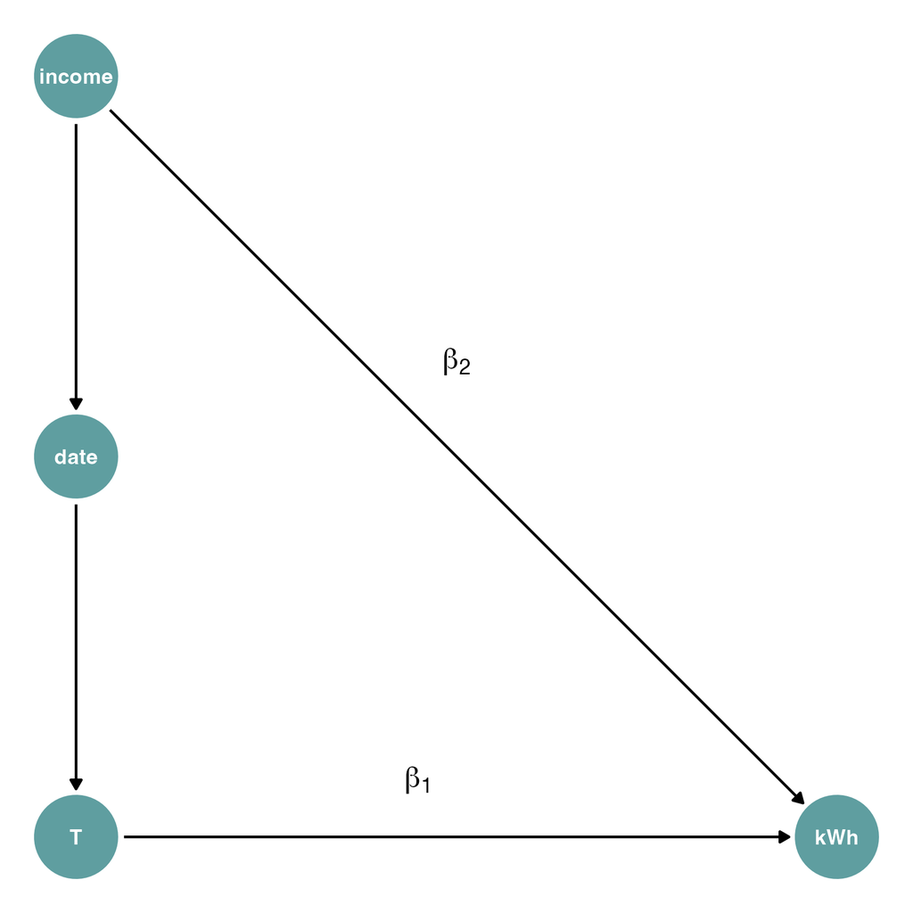

### Configuration

Our goal is to have parameters that are consistent with the data available for California. Here are some of the target values;

The median household income is California is $95,521, i.e. around $8,000 a month. For a log normal distribution, we know that $\exp(\mu) = median value$. From then on, and looking for the shape we want, we use `meanlog_income = 9` and `sdlog_income = 0.5` in the generation of the income variable.

The average monthly electricity consumption in California is around 750 kWh per month. Meaning we want $E(kWh) = 750$ in our data set.

We want the effect of the treatment between the control and the treated group at the time of summer on electricity consumption to be around - 4%, consistent with the article.

We calibrate the beta accordingly to get these values right.

Next chunk summarizes the parameters used in the simulation.

```r
baseline_param <- tibble(
  N_c = 3680000,
  N_t = 24,

  beta_1 = -60,
  beta_2 = 0.08,
  sigma_u = 50,
  sigma_n = 50,

  meanlog_income = 9,
  sdlog_income = 0.5,

  cutoff = 6,

  q = 0.9
)
kable(baseline_param)
```

| N_c | N_t | beta_1 | beta_2 | sigma_u | sigma_n | meanlog_income | sdlog_income | cutoff | q |
| --- | --- | --- | --- | --- | --- | --- | --- | --- | --- |
| 3680000 | 24 | -60 | 0.08 | 50 | 50 | 9 | 0.5 | 6 | 0.9 |

The variables are then computed through this function.

```r
generate_panel_data <- function(N_c,
                                N_t,
                                beta_1,
                                beta_2,
                                sigma_u,
                                sigma_n,
                                meanlog_income,
                                sdlog_income,
                                cutoff,
                                q) {

  household_data <- tibble(

    H_id = 1:N_c,

    baseline_income = rlnorm(N_c, meanlog_income, sdlog_income),

    date_account = ifelse(baseline_income >= quantile(baseline_income, q), sample(1:12, N_c, replace = TRUE), 0),

    D_i = ifelse(date_account < cutoff & date_account > 0, 1, 0)

  )

  panel_household_data <- household_data %>%
    uncount(N_t) %>%
    mutate(month = rep(1:N_t, times = N_c)) %>%
    arrange(H_id, month)

  panel_household_data <- panel_household_data %>%
    mutate(

      D_t = ifelse(month >= 15, 1, 0),

      D_it = D_i * D_t,

      income_noise = rnorm(N_c * N_t, 0, sigma_n),

      monthly_income = baseline_income + income_noise,

      model_noise = rnorm(N_c * N_t, 0, sigma_u),

      kWh = beta_1 * D_it + beta_2 * monthly_income + model_noise

  )

  panel_household_data <- panel_household_data %>%
    relocate( baseline_income,.before = income_noise)

  panel_household_data <- panel_household_data %>%
    relocate( month,.before = date_account)

  return(panel_household_data)
}

fake_data <- baseline_param |>
  purrr::pmap(.f = generate_panel_data) |>
  list_rbind()
```

## Tests and analysis

### Checking the distributions

We can start by checking the distributions to verifiy that our DGP is correctly calibrated.

#### Income

```r
plot_income <- ggplot(fake_data, aes(x = baseline_income)) +
  geom_density(fill = "cadetblue", color = "cadetblue", alpha = 0.5) +
  geom_function(fun = function(x) dlnorm(x, meanlog = meanlog_income, sdlog = sdlog_income), color = "darkred") +
  geom_vline(aes(xintercept = mean(baseline_income)), color = "darkblue", linetype = "dashed", linewidth = 1) +
  labs(title = "Distribution of baseline income",
       x = "Baseline income",
       y = "Density") +
  theme_minimal()

ggsave("Income_distribution.png", plot = plot_income, width = 8, height = 6)
```

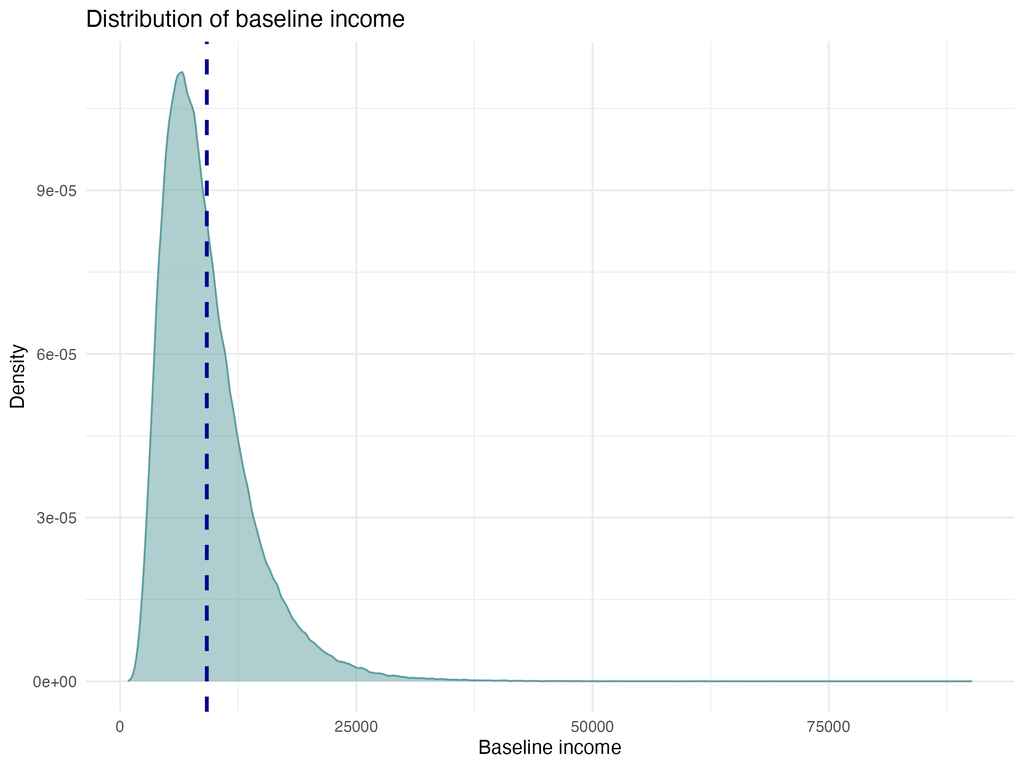

```r
mean(fake_data$baseline_income)
```

```
[1] 9179.773
```

Median income and average income are roughly the size we want them to be.

#### Electricity consumption

```r
plot_cons <- ggplot(fake_data, aes(x = kWh)) +
  geom_density(fill = "cadetblue", color = "cadetblue", alpha = 0.5) +
  geom_vline(aes(xintercept = mean(kWh)), color = "darkblue", linetype = "dashed", linewidth = 1) +
  labs(title = "Distribution of electricity consumption",
       x = "Consumption in kWh",
       y = "Density") +
  theme_minimal()

ggsave("Consumption_distribution.png", plot = plot_cons, width = 8, height = 6)
```

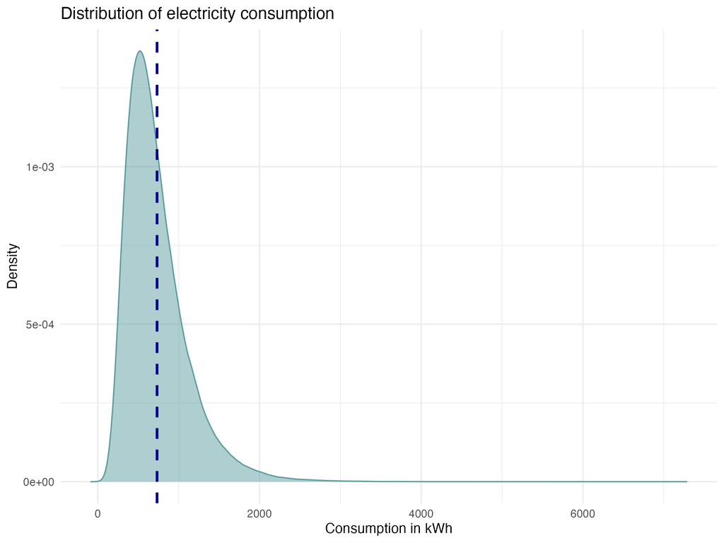

```r
mean(fake_data$kWh)
```

```
[1] 733.34
```

We find a value around 750 kWh, close to our target.

#### Treatment allocation

```r
data_account_2004 <- filter(fake_data, date_account != 0 & date_account <= 12)
```

```r
rm(fake_data)
gc()
```

We then observe the number of individuals treated in our sample.

```r
number_observations <- data_account_2004 %>%
  filter(D_it == 1) %>%
  summarise(n = n()) %>%
  pull(n)

print(number_observations / 10)
```

```
[1] 153348
```

With a N_c = 300,000 only, there are approximately 12,500 individuals that have D_i activated. All of them opened an account between January 2004 and June 2004 (not included). All of them also have D_t activated for their monthly electricity consumption between March 2005 (t = 15) and December 2005 (t = 24).

With a N_c = 3,680,000, there are approximately 153,000 individuals that have D_i activated.

We see here that even before restraining to the bandwidth, only a small subsample will be included in our regression even when we start with a huge sample of N_c = 3,680,000. This is one of the major difficulies of the RD design!

```r
data_account_2004 %>%
  filter(month >= 15) %>%
  group_by(D_i) %>%
  summarise(mean_kWh = mean(kWh),
            sd_kWh = sd(kWh)) %>%
  kable()
```

| D_i | mean_kWh | sd_kWh |
| --- | --- | --- |
| 0 | 1595.277 | 391.6197 |
| 1 | 1533.301 | 386.9130 |

Here we compare the means of electricity consumption in spring 2005 and after for customers who opened an account in 2004 before the cutoff date and those who opened it after the cutoff date in 2004, who were not enrolled in the program. We retrieve here the effect of our treatment on consumption!

On the following plot, we observe the same thing.

```r
plot3 <- data_account_2004 %>%
  mutate(account_status = if_else(
    date_account < 6 & date_account > 0,
    "Pre-cutoff",
    "Post-cutoff"
  )) %>%
ggplot(
       aes(x = month,
           y = kWh,
           color = account_status)) +
  stat_summary(
    fun = mean,
    geom = "line"
  ) +
  labs(
    title = "Average Electricity Consumption Over Time",
    x = "Month",
    y = "Consumption",
    color = "Account Type"
  ) +
  theme_minimal()

ggsave("Consumption_cutoff.png", plot = plot3, width = 8, height = 6)
```

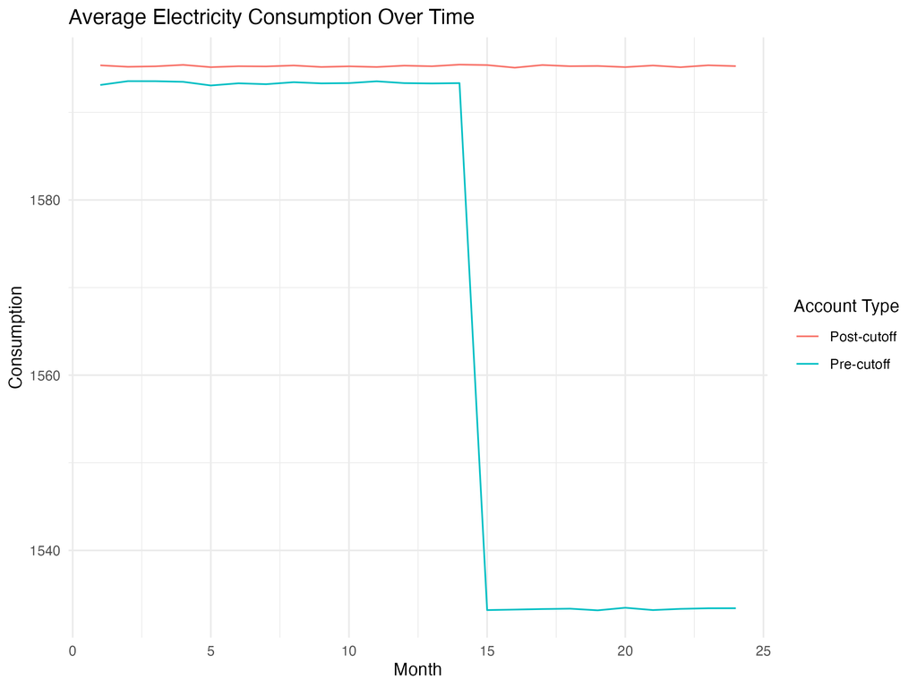

We can also briefly check that the value we choose for ß1 enables us to find the -4% effect on consumption of treated group which is presented in the article.

```r
# Calculer la moyenne de kWh pour chaque individu pour les mois non traités (1 à 14)
not_treated <- data_account_2004 %>%
  filter(month >= 1 & month <= 14) %>%
  group_by(H_id) %>%
  summarise(mean_not_treated = mean(kWh, na.rm = TRUE))

# Calculer la moyenne de kWh pour chaque individu pour les mois traités (après mois 14)
treated <- data_account_2004 %>%
  filter(month > 14) %>%
  group_by(H_id) %>%
  summarise(mean_treated = mean(kWh, na.rm = TRUE))


all_means <- not_treated %>%
  left_join(treated, by = "H_id")

# Calculer le pourcentage de variation entre les moyennes traitées et non traitées
all_means <- all_means %>%
  mutate(percentage_variation = (mean_treated - mean_not_treated) / mean_not_treated * 100)

kable(head(all_means))
```

| H_id | mean_not_treated | mean_treated | percentage_variation |
| --- | --- | --- | --- |
| 2 | 1772.375 | 1779.915 | 0.4253912 |
| 4 | 1801.933 | 1709.641 | -5.1218537 |
| 11 | 1903.530 | 1921.329 | 0.9350366 |
| 33 | 1358.143 | 1276.089 | -6.0416685 |
| 40 | 1805.907 | 1805.377 | -0.0293378 |
| 44 | 1648.634 | 1567.382 | -4.9284815 |

```r
rm(all_means)
rm(not_treated)
rm(treated)
rm(number_observations)
gc()
```

### Analysis

#### Regressions varying bandwidth sizes

```r
bandwidth = 2

bandwidth2_data <- data_account_2004 %>%
  filter(abs(date_account - 6) <= bandwidth)

model_test <- lm(kWh ~ D_it + monthly_income, data = bandwidth2_data)

coefficients_table <- coef(summary(model_test)) %>%
  as.data.frame()
kable(coefficients_table, digits = 3)
```

|  | Estimate | Std. Error | t value | Pr(>\|t\|) |
| --- | --- | --- | --- | --- |
| (Intercept) | -0.186 | 0.112 | -1.664 | 0.096 |
| D_it | -60.027 | 0.070 | -857.896 | 0.000 |
| monthly_income | 0.080 | 0.000 | 14784.197 | 0.000 |

```r
bandwidth_values <- 1:5

add_stars <- function(p_value) {
  if (p_value < 0.001) {
    return("***")
  } else if (p_value < 0.01) {
    return("**")
  } else if (p_value < 0.05) {
    return("*")
  } else if (p_value < 0.1) {
    return(".")
  } else {
    return("")
  }
}

run_regression <- function(bandwidth) {
  bandwidth_data <- data_account_2004 %>%
    filter(abs(date_account - 6) <= bandwidth)

  model_test <- lm(kWh ~ D_it + monthly_income, data = bandwidth_data)

  model_summary <- summary(model_test)

  slope_p_star <- add_stars(model_summary$coefficients[2, 4])

  data.frame(
    bandwidth = bandwidth,
    intercept = model_summary$coefficients[1, 1],
    estimate = model_summary$coefficients[2, 1],
    slope_significance = slope_p_star
  )
}

results <- map_dfr(bandwidth_values, run_regression)

print(results)
```

```
  bandwidth   intercept  estimate slope_significance
1         1 -0.34580510 -59.98008                ***
2         2 -0.18569210 -60.02680                ***
3         3 -0.06303594 -60.03003                ***
4         4 -0.09378751 -60.04845                ***
5         5 -0.11215572 -60.03124                ***
```

We clearly observe that estimates are all statistically significant for every bandwidth sizes. Indeed, this very simple DGP does not introduce the trade-off between bias and power we usually have in RD designs.

We can now drop once again our biggest sample. We will only use our bandwidth2_data since we saw that varying bandwidth’s size does not change the estimate. We thus choose a small bandwidth to simulate less data.

```r
rm(data_account_2004)
rm(model_test)
gc()
```

We can first estimate a model with only D_it as explanatory variable, this will be our regression 1.

```r
test_reg1 <- lm(kWh ~ D_it, data = bandwidth2_data)

stargazer(test_reg1, type = "text",
          title = "Regression 1 for bandwidth = 2",
          out = "regression_results1.txt")
```

```
Regression 1 for bandwidth = 2
===================================================
                          Dependent variable:
                    -------------------------------
                                  kWh
---------------------------------------------------
D_it                          -62.105***
                                (0.544)

Constant                     1,594.773***
                                (0.222)

---------------------------------------------------
Observations                   3,676,296
R2                               0.004
Adjusted R2                      0.004
Residual Std. Error     388.628 (df = 3676294)
F Statistic         13,031.890*** (df = 1; 3676294)
===================================================
Note:                   *p<0.1; **p<0.05; ***p<0.01
```

This simple regression gives estimates that a overestimates a bit the treatment because of the endogeneity issue since we do not control for income.

```r
test_reg2 <- lm(kWh ~ D_it + monthly_income, data = bandwidth2_data)

stargazer(test_reg2, type = "text",
          title = "Regression 2 for bandwidth = 2",
          out = "regression_results2.txt")
```

```
Regression 2 for bandwidth = 2
========================================================
                            Dependent variable:
                    ------------------------------------
                                    kWh
--------------------------------------------------------
D_it                             -60.027***
                                  (0.070)

monthly_income                    0.080***
                                 (0.00001)

Constant                          -0.186*
                                  (0.112)

--------------------------------------------------------
Observations                     3,676,296
R2                                 0.984
Adjusted R2                        0.984
Residual Std. Error        49.983 (df = 3676293)
F Statistic         109,680,153.000*** (df = 2; 3676293)
========================================================
Note:                        *p<0.1; **p<0.05; ***p<0.01
```

#### Regression with fixed effects

We try to introduce fixed effects in our model to replicate the design of Ito 2005 and to assess how it could work in the context of our data generating process. It also solves the endogeneity issues of our DGP.

```r
fe_reg <- feols(
  fml = kWh ~ D_it | H_id + month,
  data = bandwidth2_data)

modelsummary(fe_reg,
             title = "Regression 3 for bandwidth = 2")
```

Regression 3 for bandwidth = 2

|  | (1) |
| --- | --- |
| D_it | −59.971 |
|  | (0.108) |
| Num.Obs. | 3676296 |
| R2 | 0.984 |
| R2 Adj. | 0.983 |
| R2 Within | 0.080 |
| R2 Within Adj. | 0.080 |
| AIC | 39367109.8 |
| BIC | 41376737.3 |
| RMSE | 49.09 |
| Std.Errors | by: H_id |
| FE: H_id | X |
| FE: month | X |

The introduction of individual and time fixed effects allows to bypass the endogeneity issue in theory butt we do not observe very different estimates between our three regressions results. With fixed effects, we observe that we always retrive the effect of interest even with a very very small number of customers (N_c < 5,000), which is not the case for the two other models.

We can also compare the three models we tested.

```r
modelsummary(list("Model 1" = test_reg1,
                  "Model 2" = test_reg2,
                  "Model FE" = fe_reg),
             title = "Our Three Different Models")
```

Our Three Different Models

|  | Model 1 | Model 2 | Model FE |
| --- | --- | --- | --- |
| (Intercept) | 1594.773 | −0.186 |  |
|  | (0.222) | (0.112) |  |
| D_it | −62.105 | −60.027 | −59.971 |
|  | (0.544) | (0.070) | (0.108) |
| monthly_income |  | 0.080 |  |
|  |  | (0.000) |  |
| Num.Obs. | 3676296 | 3676296 | 3676296 |
| R2 | 0.004 | 0.984 | 0.984 |
| R2 Adj. | 0.004 | 0.984 | 0.983 |
| R2 Within |  |  | 0.080 |
| R2 Within Adj. |  |  | 0.080 |
| AIC | 54273606.1 | 39193837.4 | 39367109.8 |
| BIC | 54273645.4 | 39193889.9 | 41376737.3 |
| Log.Lik. | −27136800.032 | −19596914.725 |  |
| F | 13031.894 | 109680153.427 |  |
| RMSE | 388.63 | 49.98 | 49.09 |
| Std.Errors |  |  | by: H_id |
| FE: H_id |  |  | X |
| FE: month |  |  | X |

#### Regression and simulation functions

To make things more clean and run an entire simulation more easily, we can define functions for regression and simulation. However, with our number of observations, we do not run our simulations thanks to these functions.

```r
run_estim1 <- function(bandwidth2_data) {
  lm(kWh ~ D_it, data = bandwidth2_data) |>
    summary() |>
    broom::tidy(conf.int = TRUE, conf.level = 0.95)
}

reg1 <- baseline_param |>
  pmap(generate_panel_data) |>
  list_rbind() |>
  run_estim1()

print(reg1)
```

```r
run_estim2 <- function(bandwidth2_data) {
  lm(kWh ~ D_it + monthly_income, data = bandwidth2_data) |>
    summary() |>
    broom::tidy(conf.int = TRUE, conf.level = 0.95)
}

reg2 <- baseline_param |>
  pmap(generate_panel_data) |>
  list_rbind() |>
  run_estim2()

print(reg2)
```

```r
run_estim3 <- function(bandwidth2_data) {
  fixest::feols(
    fml = kWh ~ D_it + monthly_income | H_id + month,
    data = bandwidth2_data
  ) |>
    broom::tidy(conf.int = TRUE, conf.level = 0.95)
}

reg3 <- baseline_param |>
  pmap(generate_panel_data) |>
  list_rbind() |>
  run_estim3()

print(reg3)
```

For simulation functions:

```r
compute_sim3 <- function(...) {
  generate_panel_data(...) %>%
    run_estim3() %>%
    cbind(as_tibble(list(...)))
}

baseline_param |>
  pmap(compute_sim3) |>
  list_rbind() |>
  kable()
```

#### Towards iterating process

##### Repeating the simulation

Iterating is not possible for this size of samples since our R memory is restricted. However, with more memory we could have run the following codes. We also runned these codes for N_c = 300,000 annd found that our three regression models worked well, even if the regression model 1 (without controlling for income and without fixed effects) is a little bit biased.

```r
n_iter <- 30

param <- baseline_param |>
  uncount(n_iter)

param |>
  slice(1:10) |>
  kable()

result_sim3 <- pmap(param, compute_sim3) |>
  list_rbind()

result_sim3 |>
  kable()
```

```r
mean_repeat <- mean(result_sim3$estimate)
mean_repeat

sd_repeat <- sd(result_sim3$estimate)
sd_repeat
```

To visualize better the results of our iteration, we could have plot the following graph.

```r
result_filtered <- result_sim3 %>%
  filter(term == "D_it") %>%
  mutate(sim_id = row_number())

plot_6 <- result_filtered |>
  arrange(sim_id) |>
  slice(1:30) |>
  ggplot(aes(x = sim_id, y = estimate)) +
  geom_point() +
  geom_pointrange(aes(ymin = conf.low, ymax = conf.high)) +
  geom_hline(yintercept = -60, linetype = "solid") +
  labs(
    title = "Estimates of the ATE",
    subtitle = paste("Computed on 30 different datasets for N_c = 300,000"),
    x = "Simulation id",
    y = "Estimate"
  )
ggsave("Estimate_ATE_30.png", plot = plot_6, width = 8, height = 6)
```

We can however run this code for N_c = 300,000 customers only. For instance, we obtained the following graph for the third regression.

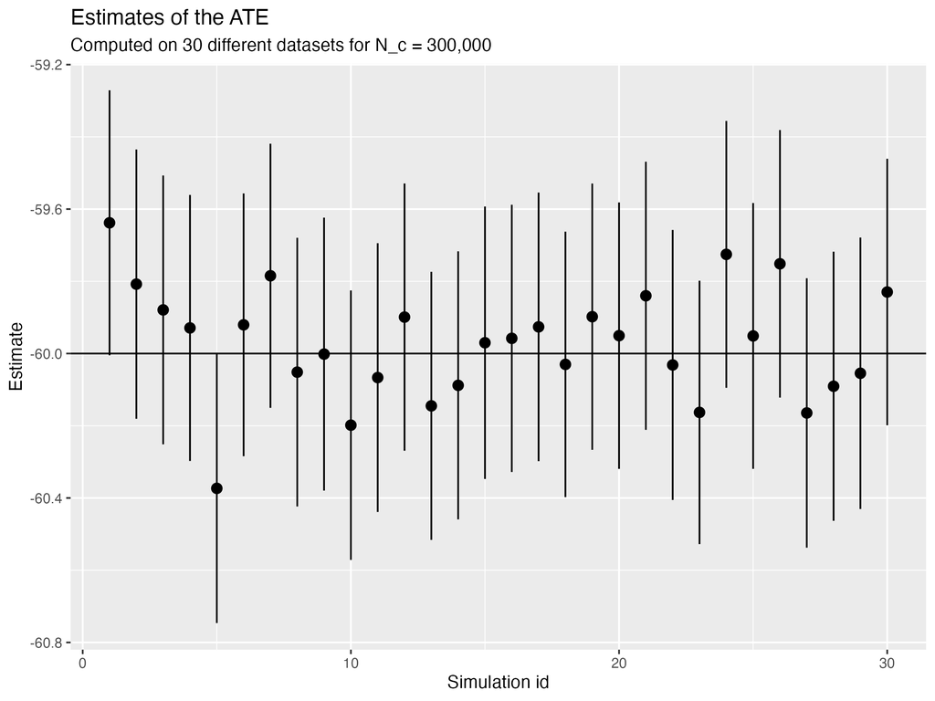

Varying the number of observations

Since our sample size is too big, we are not able to compute the iterations that will help us to understand easily and rapidly for which sample size our design will have led to unaccurate estimates. Indeed, for 3,680,000 customers, it is obvious that our estimates are good. However, testing a vector of different sample sizes with the following code (which we cannot run without crashing R) could have given us this information.

This code is including a vector of different values for N_c (the number of customers) from 500,000 to 4,000,000 with 500,000 more observations each time.

```r
n_iter <- 30

vect_n <- seq(from = 500000, to = 4000000, by = 500000)

param_var_N_c <- baseline_param |>
  select(-N_c) |>
  crossing(N_c = vect_N_c) |>
  uncount(n_iter)

param_var_N_c |>
  kable() |>
  scroll_box(height = "200px", width = "100%")

sim_res_var_N_c <- param_var_N_c |>
  pmap(compute_sim2, .progress = TRUE) |>
  list_rbind()


sim_power_var_N_c <- sim_res_var_N_c |>
  mutate(signif = (p.value < 0.05)) |>
  group_by(N_c) |>
  summarise(
    power = mean(signif),
    se_power = sd(signif)
  )

sim_power_var_N_c |>
  kable()

# plotting

sim_power_var_N_c |>
  ggplot(aes(x = N_c, y = power)) +
  geom_point() +
  geom_line() +
  labs(
    title = "Statistical Power as Function of Sample Size",
    subtitle = paste("Computed with", n_iter, "simulations"),
    x = "Number of customers",
    y = "Statistical Power"
  )
```

We can still run our simulation for others numbers of customers, one at each time.

```r
baseline_param <- tibble(
  N_c = 500000,
  N_t = 24,

  beta_1 = -60,
  beta_2 = 0.08,
  sigma_u = 50,
  sigma_n = 50,

  meanlog_income = 9,
  sdlog_income = 0.5,

  cutoff = 6,

  q = 0.9
)

generate_panel_data <- function(N_c,
                                N_t,
                                beta_1,
                                beta_2,
                                sigma_u,
                                sigma_n,
                                meanlog_income,
                                sdlog_income,
                                cutoff,
                                q) {

  household_data <- tibble(

    H_id = 1:N_c,

    baseline_income = rlnorm(N_c, meanlog_income, sdlog_income),

    date_account = ifelse(baseline_income >= quantile(baseline_income, q), sample(1:12, N_c, replace = TRUE), 0),

    D_i = ifelse(date_account < cutoff & date_account > 0, 1, 0)

  )

  panel_household_data <- household_data %>%
    uncount(N_t) %>%
    mutate(month = rep(1:N_t, times = N_c)) %>%
    arrange(H_id, month)

  panel_household_data <- panel_household_data %>%
    mutate(

      D_t = ifelse(month >= 15, 1, 0),

      D_it = D_i * D_t,

      income_noise = rnorm(N_c * N_t, 0, sigma_n),

      monthly_income = baseline_income + income_noise,

      model_noise = rnorm(N_c * N_t, 0, sigma_u),

      kWh = beta_1 * D_it + beta_2 * monthly_income + model_noise

  )

  panel_household_data <- panel_household_data %>%
    relocate( baseline_income,.before = income_noise)

  panel_household_data <- panel_household_data %>%
    relocate( month,.before = date_account)

  return(panel_household_data)
}

fake_data <- baseline_param |>
  purrr::pmap(.f = generate_panel_data) |>
  list_rbind()

data_account_2004 <- filter(fake_data, date_account != 0 & date_account <= 12)

rm(fake_data)
rm(plot_income)
rm(plot_cons)
gc()

bandwidth = 2

bandwidth2_data <- data_account_2004 %>%
  filter(abs(date_account - 6) <= bandwidth)

rm(data_account_2004)
rm(model_test)
gc()


run_estim3 <- function(bandwidth2_data) {
  fixest::feols(
    fml = kWh ~ D_it + monthly_income | H_id + month,
    data = bandwidth2_data
  ) |>
    broom::tidy(conf.int = TRUE, conf.level = 0.95)
}

reg3 <- baseline_param |>
  pmap(generate_panel_data) |>
  list_rbind() |>
  run_estim3()

summary(reg3)

compute_sim3 <- function(...) {
  generate_panel_data(...) %>%
    run_estim3() %>%
    cbind(as_tibble(list(...)))
}

baseline_param |>
  pmap(compute_sim3) |>
  list_rbind() |>
  kable()

n_iter <- 30

param <- baseline_param |>
  uncount(n_iter)

param |>
  slice(1:10) |>
  kable()

result_sim3 <- pmap(param, compute_sim3) |>
  list_rbind()

result_sim3 |>
  kable()

# to obtain the graph
result_filtered <- result_sim %>%
  filter(term == "D_it") %>%
  mutate(sim_id = row_number())

plot_6 <- result_filtered |>
  arrange(sim_id) |>
  slice(1:30) |>
  ggplot(aes(x = sim_id, y = estimate)) +
  geom_point() +
  geom_pointrange(aes(ymin = conf.low, ymax = conf.high)) +
  geom_hline(yintercept = -60, linetype = "solid") +
  labs(
    title = "Estimates of the ATE",
    subtitle = paste("Computed on 30 different data sets for N_c = 500,000"),
    x = "Simulation id",
    y = "Estimate"
  )
ggsave("Estimate_ATE_30_500,000.png", plot = plot_6, width = 8, height = 6)
```

# Second simulation

The second model is aimed to provide a better background for an RDD. Indeed, the treatment was still random among the richest consumers. We need to create a non random allocation of treatment to test different sizes of bandwidth so the RDD will be irrelevant past a certain bandwidth as individuals won’t be comparable. Unfortunately, we did not have time to implement this features. Here are some insights at what we tried/would have liked to try.

## Allocating richer people around the cutoff

The first attempt consisted in adapting the DGP of the first model by allocating the richest people around the cutoff to a certain point. We tried to reach this goal modifying the previous code with this line:

`date_account = ifelse(baseline_income >= quantile(baseline_income, 0.9), sample(3:9, N_c, replace = TRUE), sample(c(1:2, 10:24), N_c, replace = TRUE))`

Unfortunately, it did not produce any difference with the first model and we had no time left to investigate further.

## Using propensity scores

In fact, the best way would be to construct a categorical variable to reach this goal. Each month every customer could have a certain chance of opening an account. The opening date of account being a dummy (1 if the customer opened the account this month, 0 if not) we might imagine a model which given the vector of characteristics, attributes a probability of opening an account. Customers with same characteristics would open accounts at the same time, avoiding the selection into treatment issue.

Unfortunately, we did not have time to explore this issue and try implementing a categorical variable.

# Third simulation

Third simulation was meant to be the more comprehensive, using many of the information contained in the article. It is a more complex approach to the issue, which takes advantage of sources of variation.

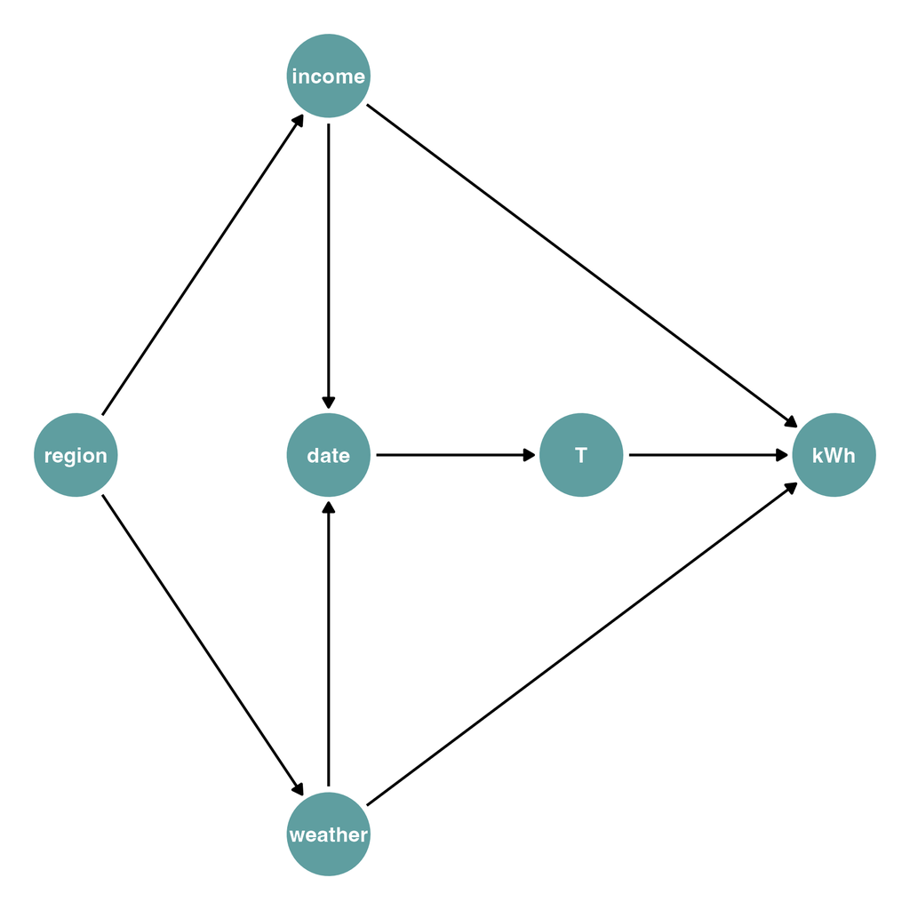

## Principle

In this model, we split consumers between a coastal and an inland area following a binomial distribution configured using the distribution shown in the article (300,000 inhabitants living in inland areas, 3,200,000 living in coastal areas). The idea is to retrive the heterogeneous effects found by Ito 2005 and understand how they influence the results.

As California has roughly 35,000,000 billion inhabitants, our sample represents (very) roughly 10% of the population. This way, customers are then allocated between 260 zip codes (10% of California’s zip codes). Those which were coastal are allocated the first 52 zip codes (20% of the area), while the inland zip codes occupy the rest of the zip codes, from 53 to 260.

Weather is generating with two vectors of monthly temperature, one from Ridgequest, an inland city, the other from Los Angeles airport. Both are monthly average temperature. These temperatures are measured by 37 of California’s 370 weather stations. The weather stations are randomly matched to zip codes following a random distribution. On average, there shall be a weather station for 7 zip codes. Every month, the weather station draw a temperature from a normal distribution centered on the average temperature vector. This temperature is then associated with all the zip codes within the area of this weather station.

## A glimpse at what we add time to implement

Here are some of the new baseline parameters required.

```r
# Montly mean temperatures for coastal and inland California for those 2 years

  # Ridgecrest is the reference for inland

monthly_inland_temperature <- c(8.1,
8.9, 12.6, 15.9, 20.8, 26.2, 29.6, 28.5, 25, 18.5, 12.3, 7.5)

  # Los Angeles airport is the reference for coastal

monthly_coastal_temperature <- c(14.7,
15.0, 16.2, 17.6, 18.8, 20.7, 22.9, 23.7,23.1, 20.7, 17.2, 14.3)
```

And some parts of the new DGP. We actually had no time to implement the DGP of the first and second simulation in this more complex model, meaning the formulas used to generate the income and the consumption are obsolete.

```r
household_data <- tibble(

  #Generating households ID's

  H_id = 1:N_c,

  #Allocating them between coastal and inland regions following the distribution in the paper

  coastal_or_inland = rbinom(N_households, size = 1, prob = 3200000 / 3500000),

  #Generating zip codes

  zip_code = ifelse(
    coastal_or_inland == 1,

    #If coastal, the househould is allocated in 20% of the territory (a fifth of on tens of California zip codes

    sample(1:52, size = N_households, replace = TRUE),

    #And vice versa

    sample(53:260, size = N_households, replace = TRUE)
  ),

  #Generating income

    #Generating the income distribution

  income = rlnorm(N_households, meanlog = meanlog_income, sdlog = sdlog_income),

    #Generating the error term

  e = rnorm(N_households, 0, sigma_e),

  u = rnorm(N_households, 0, sigma_u)

)

# Assigning weather stations based on zip_code. There on average a weather station for 7 zip codes.

household_data <- household_data %>%
  mutate(
    weather_station = ifelse(zip_code < 53, sample(1:7, N_households, replace = TRUE), sample(8:37, N_households, replace = TRUE))
  )


#We generate a tibble with all possible weather station and month combinations

weather_temperatures <- expand.grid(
  weather_station = unique(household_data$weather_station),
  month = 1:Time_period
) %>%
  mutate(
    temp = ifelse(
      weather_station < 8,  # Coastal weather stations
      rnorm(n(), mean = monthly_coastal_temperature[month %% 12 + 1], sd = 2),
      rnorm(n(), mean = monthly_inland_temperature[month %% 12 + 1], sd = 2)
    )
  )

#We add a time dimension to our dataset

pannel_household_data <- household_data %>%
  uncount(Time_period) %>%
  mutate(month = rep(1:Time_period, times = N_households)) %>%
  arrange(H_id, month)

#And then join it with the temperatures

pannel_household_data <- pannel_household_data %>%
  left_join(weather_temperatures, by = c("weather_station", "month"))

pannel_household_data <- pannel_household_data %>%
  mutate(

#Generating the opening date of the account

    #The model

  open_account = alpha_0 + alpha_1 * income + alpha_2 * temp + e,

    #Is transformed into a time variable

  date_account = ifelse(open_account >= quantile(open_account, 0.9), sample(1:Time_period, N_households, replace = TRUE), NA),

#Generating the treatments

  x = date_account - bandwidth,

  D_i = ifelse(x < 0, 1, 0),

  D_t = ifelse(abs(x) <= bandwidth, 1, 0),

  D_it = D_i * D_t,

    #Generating the consumption

  K_it = beta_0 + beta_1 * D_it + beta_2 * income + beta_3 * temp + u)
```